# boxjenkins

e-sang

# box jenkins sequence

### model identification

**stationarity**  
run sequence plot:

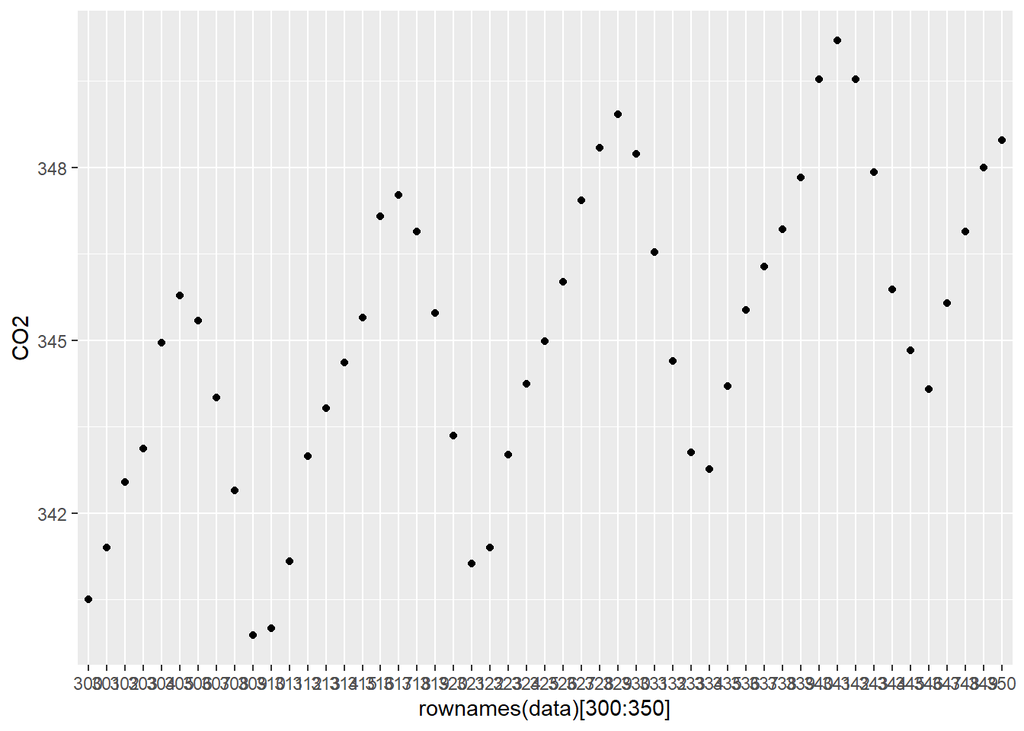

```r
ggplot(data = data[300:350,]) +
  geom_point(aes(x = rownames(data)[300:350], y = CO2))
```

shows not the same mean = non stationary  
variance probably not constant either

autocorrelation plot:

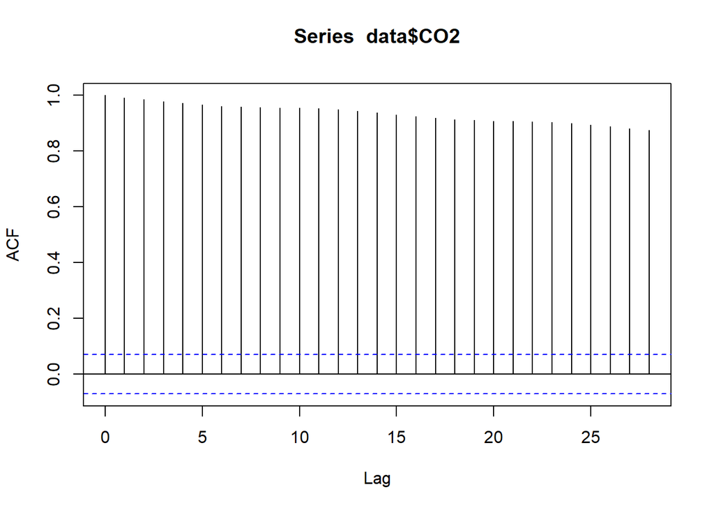

```r
acf(data$CO2, na.action = na.pass)
```

shows very slow decay - indication of non-stationarity

*adjustments*  
to adjust for non-stationarity, use differences:  
Y_i = Z_i - Z_i-1

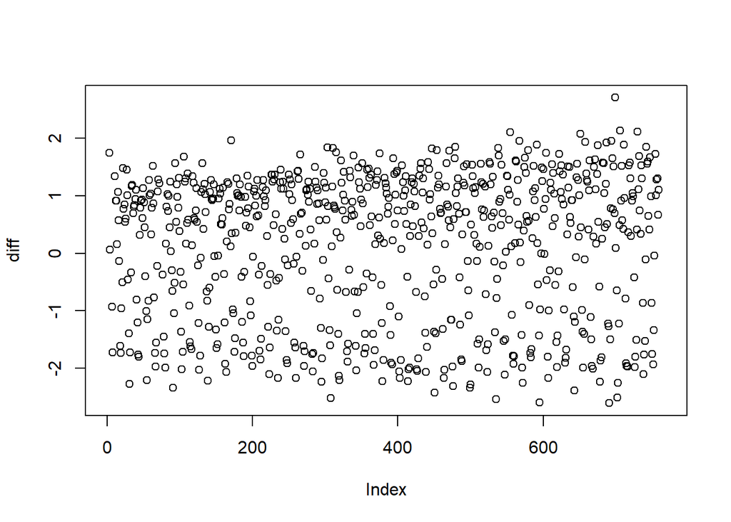

```r
diff <- diff(data$CO2)
data.diff <- ts(diff, start=c(1958,1), frequency=12)
plot(diff)
```

mean + variance look around constant

**seasonality**  
look at something called a seasonal subseries plot to see if there are differences in means between months

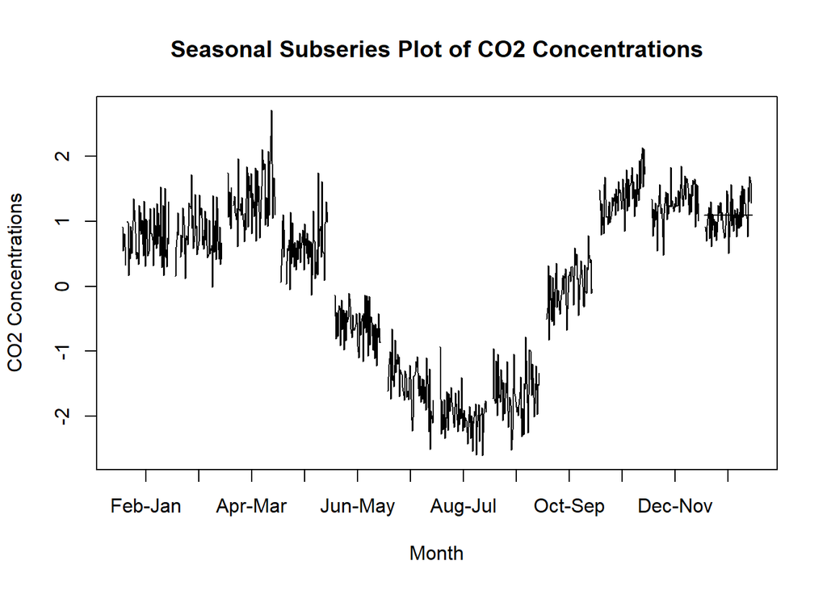

```r
par(mfrow=c(1,1))
monthplot(data.diff, phase=cycle(data.diff),
          ylab="CO2 Concentrations",
          main="Seasonal Subseries Plot of CO2 Concentrations",
          xlab="Month",
          labels=c("Feb-Jan","Mar-Feb","Apr-Mar","May-Apr",
                   "Jun-May","Jul-Jun","Aug-Jul","Sep-Aug",
                   "Oct-Sep","Nov-Oct","Dec-Nov","Jan-Dec"))
```

definitely a difference!

*adjustments*  
another difference, but this time every 12th term:

```r
diff12 <- diff(diff,12)
```

**determining q for moving average**  
at lag q + 1, the autocorrelation plot becomes 0 (within 95% CIs)  
will see this in the form MA(q)  
in R we will plug this into the arima() function in ‘order’

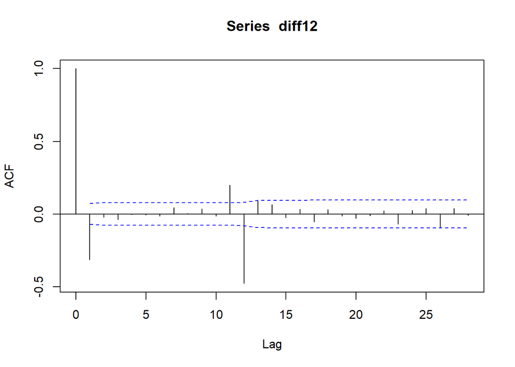

```r
acf(diff12, na.action = na.pass, ci.type = "ma")
```

since there is also a spike at lag 12, seasonal q also exists and seasonal q = 1

**determining p for autocorrelation**  
at lag p + 1, the partial autocorrelation plot becomes 0 (within 95% CIs)  
will see this in the form AR(q)  
in R we will plug this into the arima() function in ‘order’

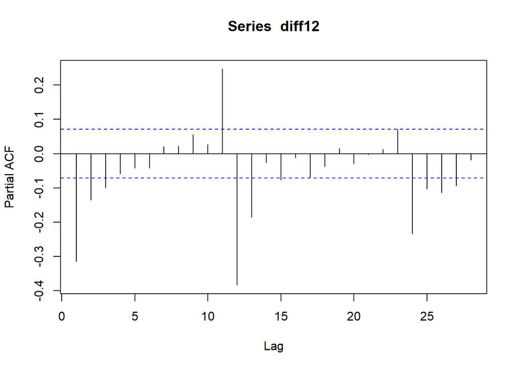

```r
pacf(diff12, na.action = na.pass)
```

p = 3; seasonal p = 1

### model estimation

```r
fit <- arima(data$CO2, order = c(3,1,2), seasonal = list(order=c(1,1,1),period=12))
summary(fit)
```

```
##
## Call:
## arima(x = data$CO2, order = c(3, 1, 2), seasonal = list(order = c(1, 1, 1),
##     period = 12))
##
## Coefficients:
##           ar1     ar2      ar3      ma1      ma2    sar1     sma1
##       -0.1198  0.1021  -0.0343  -0.2449  -0.2047  0.0135  -0.8600
## s.e.   0.7033  0.2495   0.0738   0.7025   0.4860  0.0422   0.0208
##
## sigma^2 estimated as 0.09428:  log likelihood = -185.12,  aic = 386.24
##
## Training set error measures:
##                      ME      RMSE       MAE         MPE       MAPE      MASE
## Training set 0.02598136 0.3071685 0.2417195 0.007071868 0.06801665 0.2160605
##                      ACF1
## Training set 0.0001023625
```

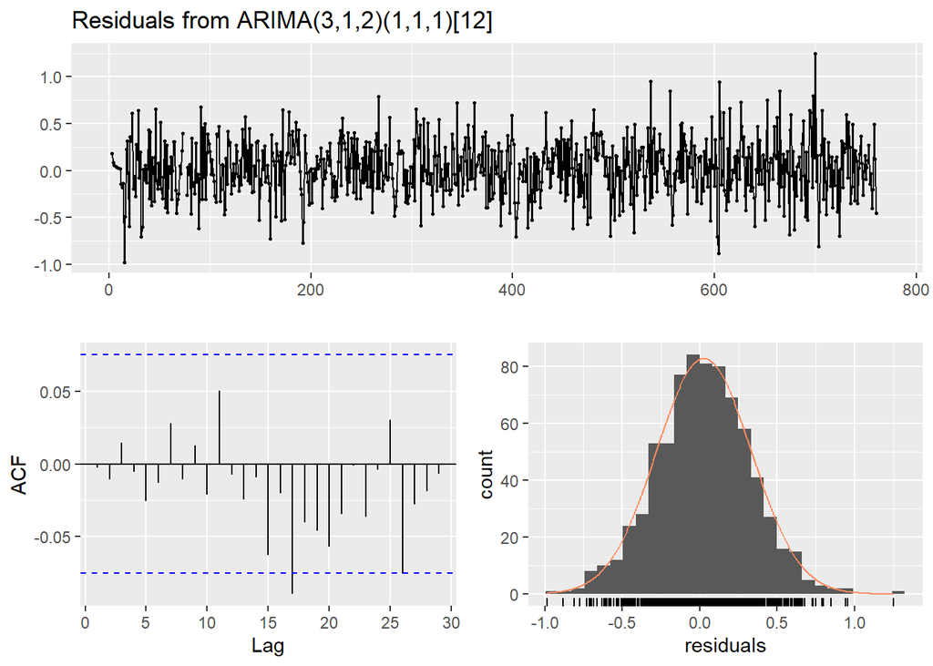

```
##
##  Ljung-Box test
##
## data:  Residuals from ARIMA(3,1,2)(1,1,1)[12]
## Q* = 0.72665, df = 3, p-value = 0.8669
##
## Model df: 7.   Total lags used: 10
```

```r
checkresiduals(fit)
```

```r
fit1 <- arima(data$CO2, order = c(3,1,1), seasonal = list(order=c(0,1,1),period=12))
summary(fit1)
```

```
##
## Call:
## arima(x = data$CO2, order = c(3, 1, 1), seasonal = list(order = c(0, 1, 1),
##     period = 12))
##
## Coefficients:
##          ar1     ar2      ar3      ma1     sma1
##       0.1871  0.0099  -0.0499  -0.5526  -0.8569
## s.e.  0.1644  0.0701   0.0517   0.1615   0.0189
##
## sigma^2 estimated as 0.09429:  log likelihood = -185.18,  aic = 382.36
##
## Training set error measures:
##                     ME      RMSE       MAE         MPE       MAPE     MASE
## Training set 0.0257522 0.3071868 0.2417491 0.007008902 0.06802457 0.216087
##                      ACF1
## Training set 0.0001968766
```

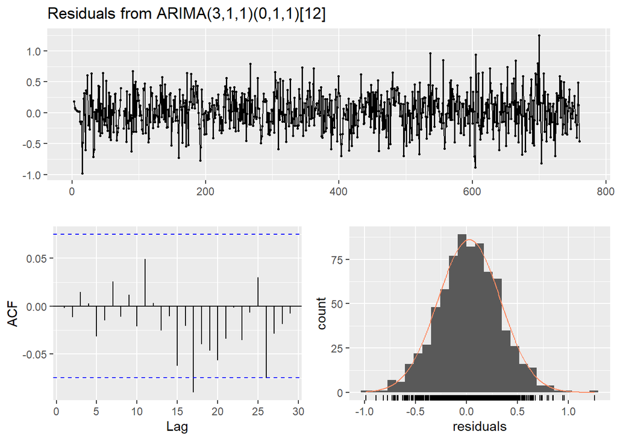

```
##
##  Ljung-Box test
##
## data:  Residuals from ARIMA(3,1,1)(0,1,1)[12]
## Q* = 0.82885, df = 5, p-value = 0.9752
##
## Model df: 5.   Total lags used: 10
```

```r
checkresiduals(fit1)
```

summary: look at AIC, loglikelihood, RMSE  
AIC: lower = better fitting (and accounts for complexity of model)  
loglikelihood: measure of model fit, didn’t really change for these two models  
RMSE: measure of residuals, lower = less residuals/better fitting

residual plots: run-sequence, acf of residuals, histogram of residuals  
run-sequence plot: shows pretty even distribution w/ no obvious pattern  
autocorrelation plot: mostly around 0, indicating random distribution of resids.  
histogram: normally distributed = good

## forecasting/model interpretation

often, interpreting the individual parameters of the model doesn’t make a lot of sense and gets real complicated real fast. it’s better to look at what the model implies to get a sense of what it means.

```r
predicted <- forecast(fit1, h=24)
predicted.dat <- data.frame(mean = predicted$mean,
                            lower.80 = predicted$lower[,1],
                            upper.80 = predicted$upper[,1],
                            lower.95 = predicted$lower[,2],
                            upper.95 = predicted$upper[,2],
                            date2 = seq(from = 2021.37, to = 2023.287, by = (1/12)))
og.dat <- data.frame(mean = data$CO2[745:760],
                     lower.80 = data$CO2[745:760],
                     upper.80 = data$CO2[745:760],
                     lower.95 = data$CO2[745:760],
                     upper.95 = data$CO2[745:760],
                     date2 = data$date2[745:760])
all.dat <- rbind(og.dat, predicted.dat)

gg <- ggplot(all.dat) +
  aes(x = date2) +
  expand_limits(x = c(2020:2023.287), y = c(400:425)) +
  scale_y_continuous(name = c("CO2 concentration (ppm)")) +
  scale_x_continuous(name = c("time (year)")) +
  geom_point(aes(y = mean), size = 2, color = "red") +
  geom_line(aes(y = mean), size = 1) +
  geom_ribbon(aes(ymin = lower.80, ymax = upper.80), fill = "blue", alpha = 0.3) +
  geom_ribbon(aes(ymin = lower.95, ymax = upper.95), fill = "blue", alpha = 0.3)
print(head(predicted.dat))
```

```
##       mean lower.80 upper.80 lower.95 upper.95    date2
## 1 417.6986 416.9772 418.4199 416.5954 418.8018 2021.370
## 2 418.4930 417.7427 419.2433 417.3455 419.6405 2021.453
## 3 419.1781 418.3999 419.9563 417.9880 420.3682 2021.537
## 4 420.7290 419.9239 421.5341 419.4977 421.9603 2021.620
## 5 421.5812 420.7344 422.4281 420.2861 422.8764 2021.703
## 6 420.8267 419.9459 421.7075 419.4796 422.1738 2021.787
```

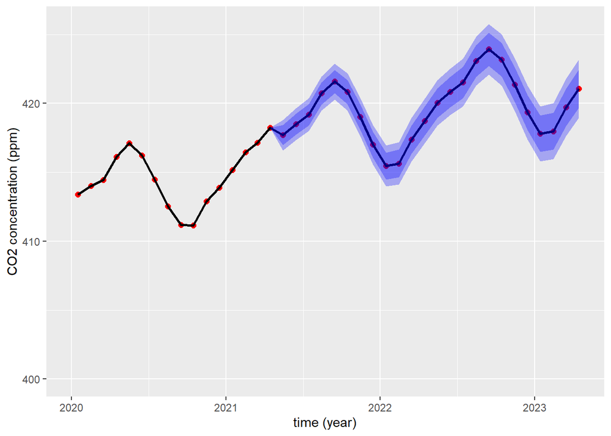

```r
print(gg)
```

```r
predicted5 <- forecast(fit1, h=60)
predicted.dat5 <- data.frame(mean = predicted5$mean,
                            lower.80 = predicted5$lower[,1],
                            upper.80 = predicted5$upper[,1],
                            lower.95 = predicted5$lower[,2],
                            upper.95 = predicted5$upper[,2],
                            date2 = seq(from = 2021.37, to = 2026.287, by = (1/12)))
og.dat <- data.frame(mean = data$CO2[745:760],
                     lower.80 = data$CO2[745:760],
                     upper.80 = data$CO2[745:760],
                     lower.95 = data$CO2[745:760],
                     upper.95 = data$CO2[745:760],
                     date2 = data$date2[745:760])
all.dat5 <- rbind(og.dat, predicted.dat5)

gg <- ggplot(all.dat5) +
  aes(x = date2) +
  expand_limits(x = c(2020:2026.287), y = c(400:435)) +
  scale_y_continuous(name = c("CO2 concentration (ppm)")) +
  scale_x_continuous(name = c("time (year)")) +
  geom_point(aes(y = mean), size = 2, color = "red") +
  geom_line(aes(y = mean), size = 1) +
  geom_ribbon(aes(ymin = lower.80, ymax = upper.80), fill = "blue", alpha = 0.3) +
  geom_ribbon(aes(ymin = lower.95, ymax = upper.95), fill = "blue", alpha = 0.3)
print(head(predicted.dat5))
```

```
##       mean lower.80 upper.80 lower.95 upper.95    date2
## 1 417.6986 416.9772 418.4199 416.5954 418.8018 2021.370
## 2 418.4930 417.7427 419.2433 417.3455 419.6405 2021.453
## 3 419.1781 418.3999 419.9563 417.9880 420.3682 2021.537
## 4 420.7290 419.9239 421.5341 419.4977 421.9603 2021.620
## 5 421.5812 420.7344 422.4281 420.2861 422.8764 2021.703
## 6 420.8267 419.9459 421.7075 419.4796 422.1738 2021.787
```

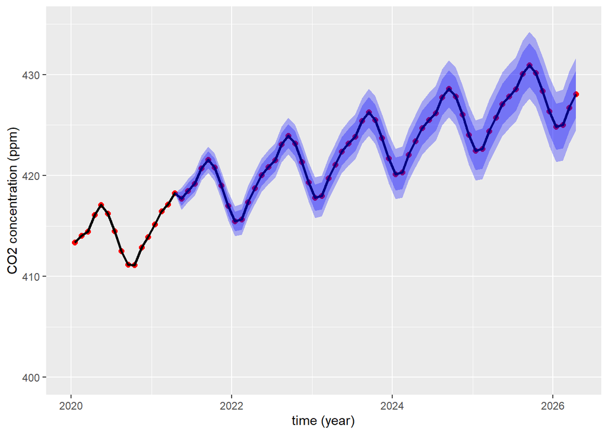

```r
print(gg)
```

blue shading: confidence intervals representing uncertainty -  
inner band: 80% of the time, the predicted value falls into that range  
outer band: 95% of the time, the predicted value falls into that range

notice that the confidence intervals get wider over time; this is because we are less confident about our prediction more into the future  
(could look at forcasts for 10 years, 20 years, 50 years etc. but they may not be great estimates and are only a function of the current data we have)